# Insights

## Bootstraped Mean Ratings

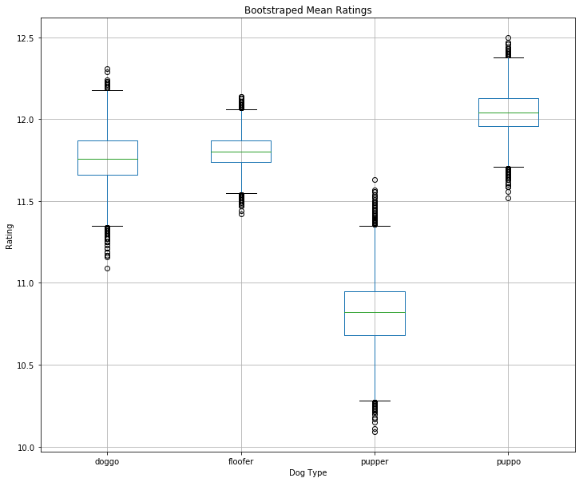

```python
from IPython.display import Image
Image("bootstrap_means.png")
```

The above figure shows the average ratings for a 10,000 samples of 100 dogs for each category. On starting this project I thought floofers would be the top rated dog, as I am a follower of We_Rate_Dogs and he often rates floofers 13/10. However while the spread of puppo means is larger than that of floofers, it's evident by their positions that puppo's get the highest overall ratings. Floofers and doggos get a similar average rating (with doggos having a higher deviation, and finally puppers on average get the lowest rating.

With all mean ratings being well above 10/10 though, I'd say they really likes all the dogs.

## Post Times

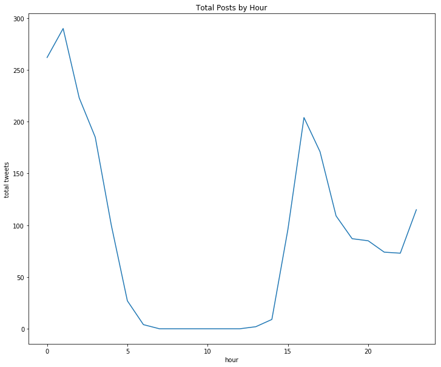

```python
Image('post_by_hour.png')
```

The figure above shows the total number of tweets by hour hour of the day. They seem to post mostly at 12am and 4pm.

## Average Public Activity per Tweet by Hour

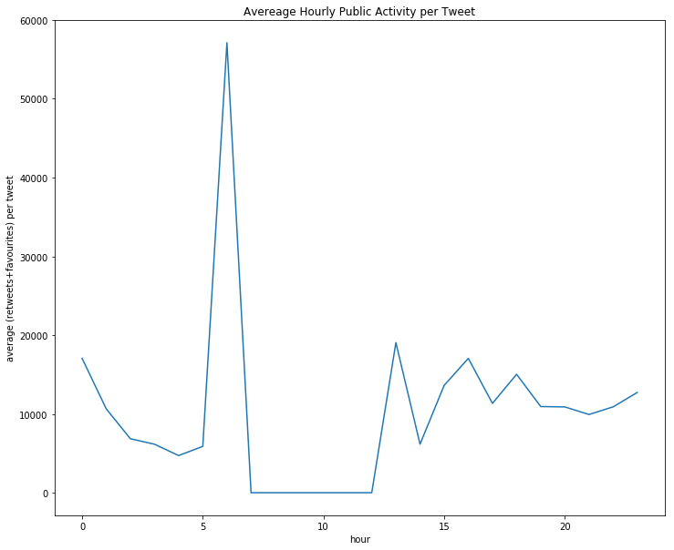

```python
Image('public_activity_by_hour.png')
```

The figure above shows the average public activity (retweets and favourites) per tweet organised by hour. It seems that all their tweets seem to get a pretty even amount of traffic with a big dip in the early morning. There is a massive spike at 6am suggesting tweets at this time average almost 60,000 retweets and favourites, however, with only 4 tweets at this time, it may just be a coincidence.